# Trabalho Final

## Lendo os dados de emissão de CO2 dos países do G20

```r
## Lendo dados
df_h <- readxl::read_excel("dados/Trabalho Inferência Estatística (Energia).xlsx")
```

## Testando normalidade dos dados

### Emissões anuais de CO2 com base no consumo

```r
df_h_can <- df_h |>
  dplyr::filter(`País` == "Canadá")

df_h_rein <- df_h |>
  dplyr::filter(`País` == "Reino Unido")

diferenca_emissao <- df_h_can$`Emissões anuais de CO2 com base no consumo` - df_h_rein$`Emissões anuais de CO2 com base no consumo`

shapiro.test(diferenca_emissao)
```

```
    Shapiro-Wilk normality test

data:  diferenca_emissao
W = 0.88233, p-value = 0.01614
```

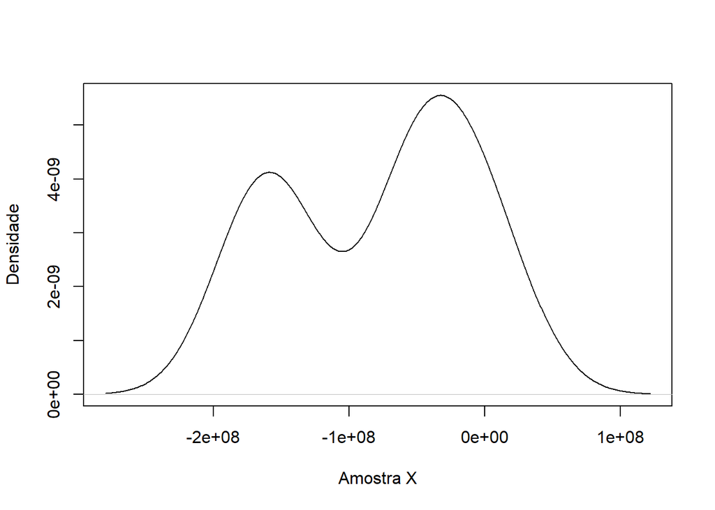

```r
plot(density(diferenca_emissao), ylab='Densidade', xlab='Amostra X', main='')
```

```r
## Canadá
shapiro.test(df_h_can$`Emissões anuais de CO2 com base no consumo`)
```

```
    Shapiro-Wilk normality test

data:  df_h_can$`Emissões anuais de CO2 com base no consumo`
W = 0.92352, p-value = 0.102
```

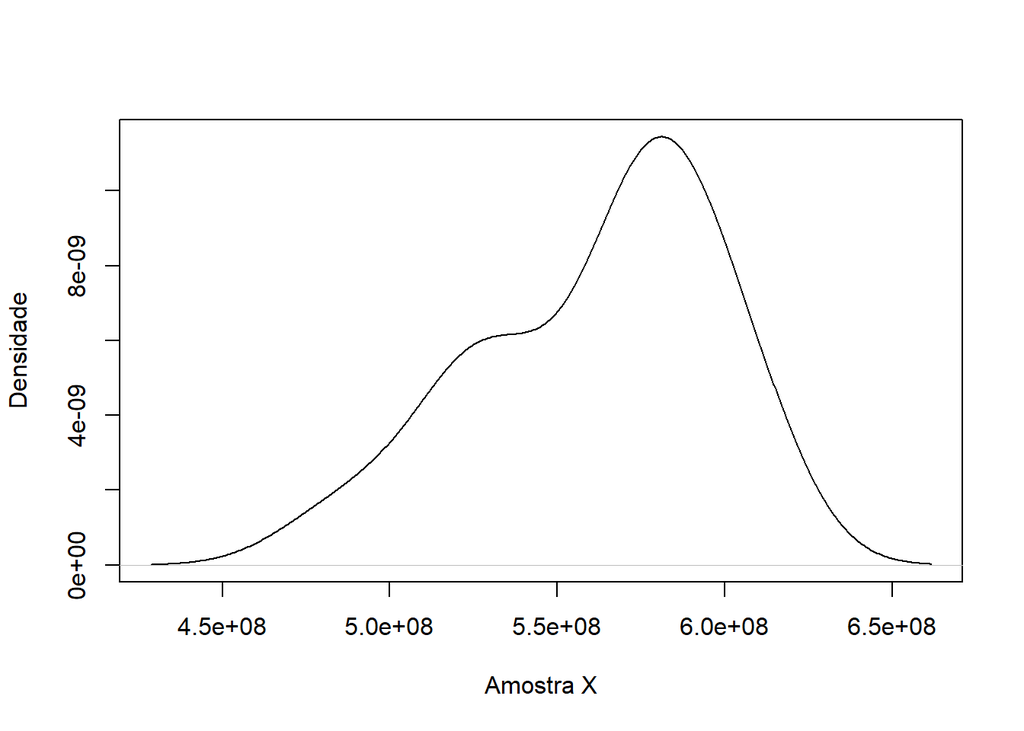

```r
plot(density(df_h_can$`Emissões anuais de CO2 com base no consumo`), ylab='Densidade', xlab='Amostra X', main='')
```

```r
## Reino Unido
shapiro.test(df_h_rein$`Emissões anuais de CO2 com base no consumo`)
```

```
    Shapiro-Wilk normality test

data:  df_h_rein$`Emissões anuais de CO2 com base no consumo`
W = 0.91565, p-value = 0.07107
```

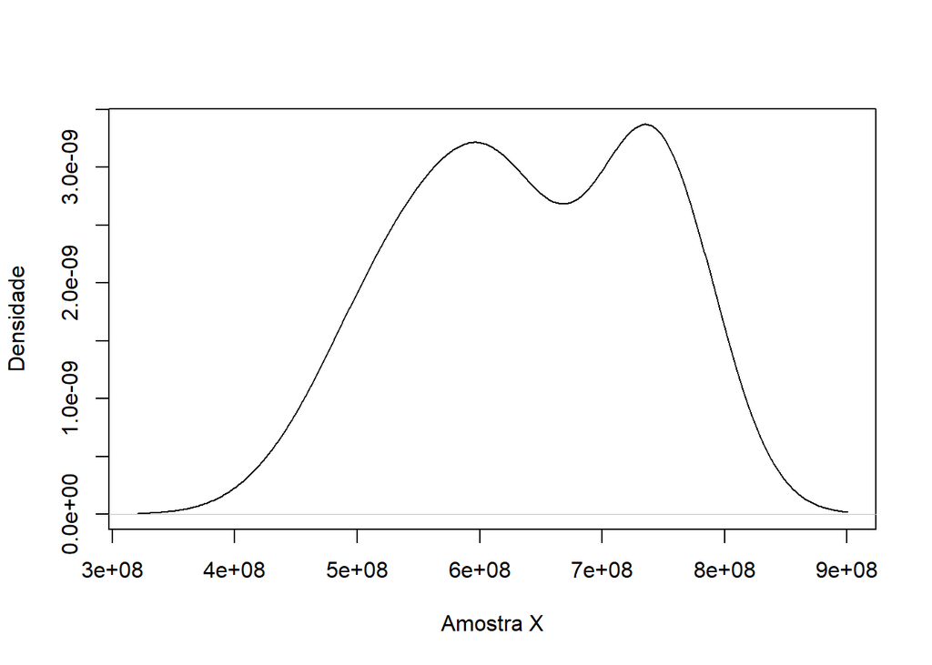

```r
plot(density(df_h_rein$`Emissões anuais de CO2 com base no consumo`), ylab='Densidade', xlab='Amostra X', main='')
```

Ou seja, ao avaliarmos a base como um todo, na diferença dos dois países, não temos normalidade nos dados, como é possível ver no primeiro gráfico e no primeiro teste.

Já quando separamos as bases por país, ambos os países apresentam valores de emissão de CO anuais que podem ser consideradas normais a um nível de significância de 5%, como é possível ver nos gráficos e nos testes de Shapiro-Wilk.

## Análise gráfica dos dados

### Emissões anuais de CO2 com base no consumo

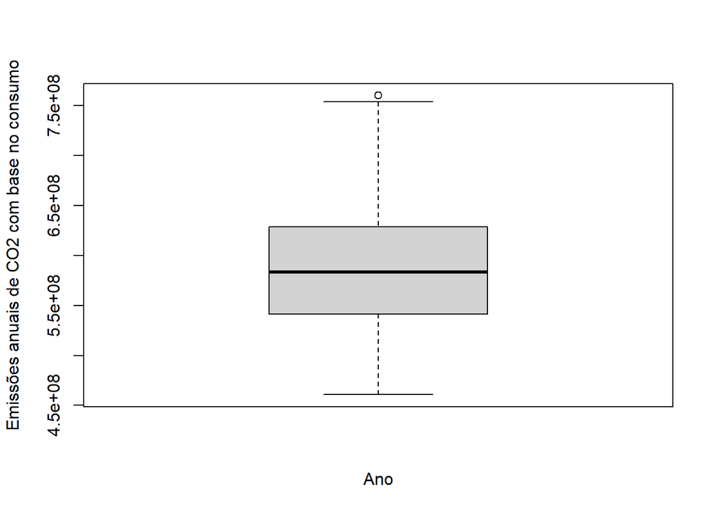

```r
boxplot(df_h$`Emissões anuais de CO2 com base no consumo`, ylab="Emissões anuais de CO2 com base no consumo", xlab="Ano")

library(ggplot2)
```

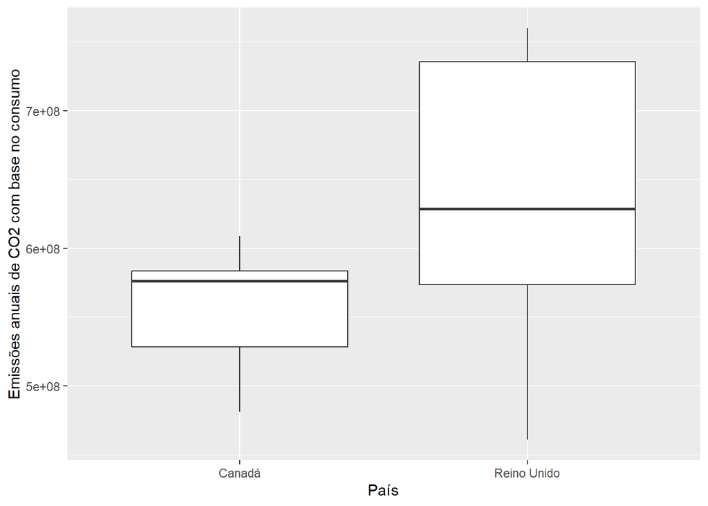

```r
ggplot(df_h, aes(x = `País`, y = `Emissões anuais de CO2 com base no consumo`)) +
  geom_boxplot()
```

## Intervalo de confiança da média de emissão para o Canadá

```r
## Canadá

media_can <- mean(df_h_can$`Emissões anuais de CO2 com base no consumo`)
desvio_padrao_can <- sd(df_h_can$`Emissões anuais de CO2 com base no consumo`)
n_can <- length(df_h_can$`Emissões anuais de CO2 com base no consumo`)
z <- qnorm(0.975)

intervalo_can <- c(media_can - z * (desvio_padrao_can / sqrt(n_can)), media_can + z * (desvio_padrao_can / sqrt(n_can)))

intervalo_can
```

```
[1] 546465635 577074020
```

```r
## Usando a função do teste t
t.test(df_h_can$`Emissões anuais de CO2 com base no consumo`, conf.level = 0.95)$conf.int
```

```
[1] 545481780 578057875
attr(,"conf.level")
[1] 0.95
```

```r
## Usando cálculo manual
alpha<-0.05
n<-length(df_h_can$`Emissões anuais de CO2 com base no consumo`)

(LI<-mean(df_h_can$`Emissões anuais de CO2 com base no consumo`)-qt(1-alpha/2, n-1)*sd(df_h_can$`Emissões anuais de CO2 com base no consumo`)/sqrt(n))
```

```
[1] 545481780
```

```r
(LS<-mean(df_h_can$`Emissões anuais de CO2 com base no consumo`)+qt(1-alpha/2, n-1)*sd(df_h_can$`Emissões anuais de CO2 com base no consumo`)/sqrt(n))
```

```
[1] 578057875
```

Temos então que o intervalo de confiança para a média de emissão de CO2 anual do Canadá é de 545481780 à 578057875, com 95% de confiança.

## Estimação pontual

Para a estimação pontual de emissão de CO2 anual para o Canadá, como possuímos uma distribuição aproximada da normal, utilizaremos a fórmula da média amostral para calcular uma distribuição normal, que é:

$$\bar{X} = \frac{\sum_{i=1}^{n} X_i}{n}$$

```r
sum(df_h_can$`Emissões anuais de CO2 com base no consumo`)/length(df_h_can$`Emissões anuais de CO2 com base no consumo`)
```

```
[1] 561769828
```

Ou seja, a estimação pontual da emissão de CO2 anual do Canadá é de 561769828.

## Teste de hipótese

```r
t.test(df_h_can$`Emissões anuais de CO2 com base no consumo`, df_h_rein$`Emissões anuais de CO2 com base no consumo`, conf.level = 0.95)
```

```
    Welch Two Sample t-test

data:  df_h_can$`Emissões anuais de CO2 com base no consumo` and df_h_rein$`Emissões anuais de CO2 com base no consumo`
t = -3.5239, df = 25.499, p-value = 0.001629
alternative hypothesis: true difference in means is not equal to 0
95 percent confidence interval:
 -124299063  -32657017
sample estimates:
mean of x mean of y
561769828 640247868
```